# CURSO DE ACTUALIZACION EN ESTADISTICA

#### Profesor: Dr. José Manuel MAGALLANES, Ph.D

## Sesión 2:

## **Exploración de Datos Categóricos**

Explorar es el primer paso del análisis estadístico. Es el momento en que, guiados por nuestros conocimientos previos, elegimos de las variables disponibles aquellas que tengan relevancia para nuestro proceso decisional.

La exploración es un proceso para darle soporte estadístico a nuestra intuición. Este proceso se hace según el tipo de variable. En esta sesión veremos la exploración de las variables categóricas.

### Parte 1. **Variable Nominales**

Las variables categóricas tienen un limitado y pequeño número de modalidades o niveles. De ahí que ver el conteo de cada una de éstas nos permite conocer la distribución de la variable.

```r
LINK='https://docs.google.com/spreadsheets/d/e/2PACX-1vSKuD4fkPOCgoRhefu9cDLzKJe-tkZ8V0EDPihgr2B6PZK3j-MGAfcSyNRQ91hzhuEh_iCebo1-8DWu/pub?gid=775750542&single=true&output=csv'
mineria=read.csv(LINK,stringsAsFactors = F)
```

Veamos nuestras variables:

```r
str(mineria)
```

```
## 'data.frame':    31 obs. of  3 variables:
##  $ Mina   : chr  "Las Bambas" "Las Bambas" "Las Bambas" "Las Bambas" ...
##  $ REGION : chr  "Apurímac" "Apurímac" "Apurímac" "Apurímac" ...
##  $ Mineral: chr  "COBRE" "ZINC" "PLATA" "ORO" ...
```

**1. Tablas de Frecuencia** La data nos informa sobre el mineral o minerales que se explota en un proyecto minero y la región donde se ubica el proyecto. Trabajemos con los minerales:

```r
table(mineria$Mineral)
```

```
##
##    COBRE DIAMANTE   HIERRO      ORO    PLATA     ZINC
##       18        1        2        7        2        1
```

Una mejor manera de producir la tabla para un formato web:

```r
library(knitr) # para 'kable'

count=table(mineria$Mineral)
share=prop.table(count)
kable(cbind(count,share),digits = 2)
```

|  | count | share |
| --- | --- | --- |
| COBRE | 18 | 0.58 |
| DIAMANTE | 1 | 0.03 |
| HIERRO | 2 | 0.06 |
| ORO | 7 | 0.23 |
| PLATA | 2 | 0.06 |
| ZINC | 1 | 0.03 |

**2. Gráficos**

El gráfico que se debe usar con las variables nominales es el de barras. R tiene muchas maneras de producir gráficas. Instalemos la librería *ggplot2* para usar su estilo de producción. La instalación se hace desde el menú: Tools/Install Packages.

Una vez instalada una biblioteca de funciones, debemos activarla con el comando **library**:

```r
library(ggplot2)
```

Cuando usamos ggplot, los gráfico se hacen por ‘capas’:

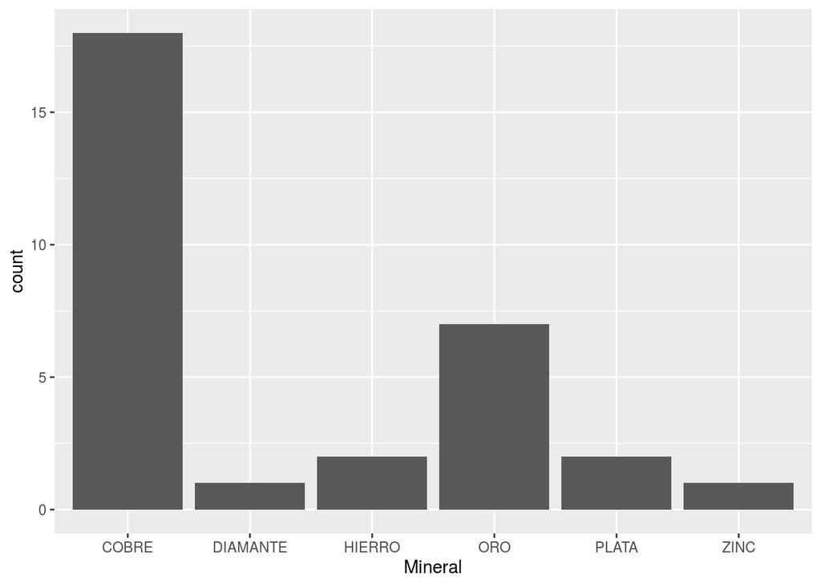

```r
# 1. Creamos la base:
base = ggplot(data=mineria,aes(x=Mineral))

# 2. Le añadimos el tipo de gráfico (o geometría a esa base).
#    Note que guarda el grafico en un objeto.
bar1 = base + geom_bar()

# 3. Muestro objeto:
bar1
```

Si deseamos porcentajes, añadimos a la base algo diferente:

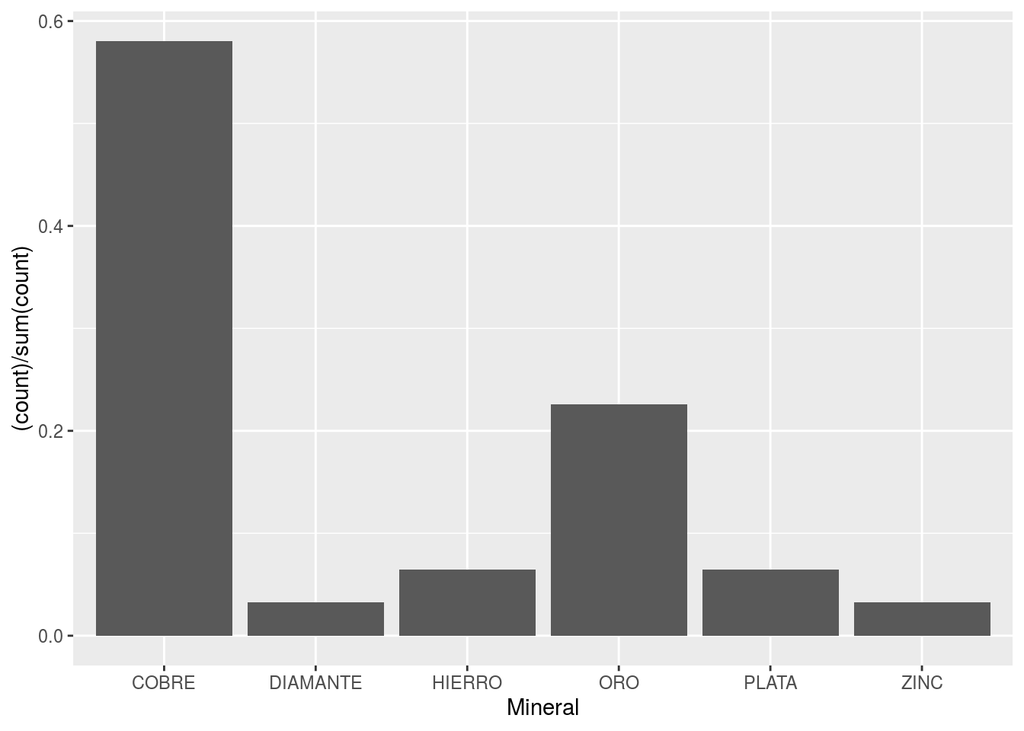

```r
bar1p = base + geom_bar(aes(y = (..count..)/sum(..count..)))
bar1p
```

Puedo alterar el eje vertical así:

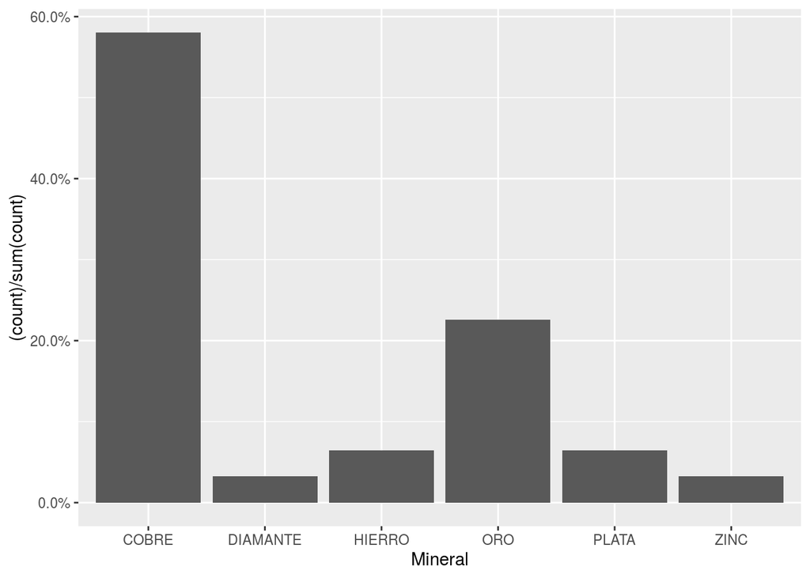

```r
library(scales) # para 'scales::percent'

bar1p = bar1p + scale_y_continuous(labels = scales::percent)
bar1p
```

Aqui puedo añadir titulos:

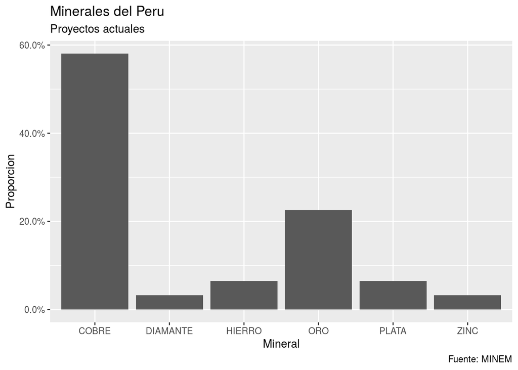

```r
bar1p + labs( y="Proporcion",
              title="Minerales del Peru",
              subtitle = "Proyectos actuales",
              caption = "Fuente: MINEM")
```

La variable es de tipo **nominal** pues los nombres de los minerales mostrados no tienen un orden más allá de lo alfabético. Lo que es más, no es que un mineral pueda pasar por todos esos estados, es simplemente su tipo. Cuando trabajamos con nominales, la mayoría de las veces no es necesario transformar la columna de tipo texto en categórica (o *factor* como se le denomina en *R*).

De las tablas de frecuencia, podemos concluir que el Cobre es el mineral que tiene más proyectos en el país. De todos modos, dado que la variable es nominal, podemos *reacomodar* el orden de presentación de las modalides usando la función **fct_infreq** de la biblioteca *forcats*:

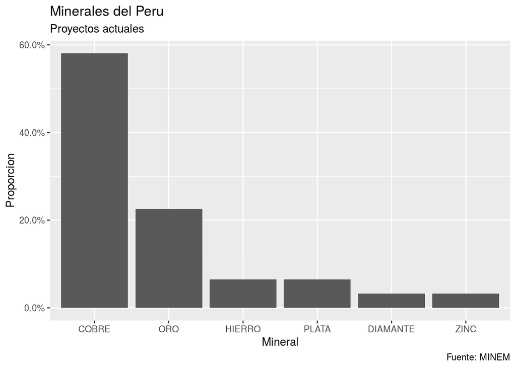

```r
library(forcats) # para 'fct_infreq'

base = ggplot(data=mineria,aes(x=fct_infreq(Mineral))) # cambio
bar1 = base + geom_bar(aes(y = (..count..)/sum(..count..)))
bar1 = bar1 + labs(x="Mineral",
                   y="Proporcion",
                   title="Minerales del Peru",
                   subtitle = "Proyectos actuales",
                   caption = "Fuente: MINEM")
bar1 + scale_y_continuous(labels = scales::percent)
```

Claro está que podemos plantear orden ascendente con **fct_rev** (también de *forcats*):

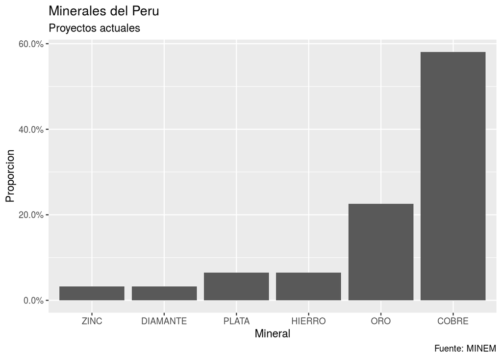

```r
base = ggplot(data=mineria,aes(x=fct_rev(fct_infreq(Mineral)))) # orden inverso
bar1 = base + geom_bar(aes(y = (..count..)/sum(..count..)))
bar1 = bar1 + labs(x="Mineral",
                   y="Proporcion",
                   title="Minerales del Peru",
                   subtitle = "Proyectos actuales",
                   caption = "Fuente: MINEM")
bar1 + scale_y_continuous(labels = scales::percent)
```

**3. Medidas de resumen**

Las variables en escala nominal tienen las siguientes medidas de resumen:

- Centralidad:
  - La moda, el valor que más se repite. Llamaremos a *DescTools*:

```r
library(DescTools) # para 'Mode'

Mode(mineria$Mineral)
```

```
## [1] "COBRE"
```

- Concentración: Este es un coeficiente que permite calificar qué tan buena es la moda, y a la vez qué tanta participación tienen los demás.Podemos usar el indice de Herfindahl- Hirschman que se interpreta así:
  - menor que 0.01 : indica que la moda no es significativa, las categorias se distribuyen uniformemente.
  - menor que 0.15 : indica que la moda no es significativa, puede haber multimodalidad.
  - entre 0.15 - 0.25: hay una moda.
  - mas de 0.25: hay una moda y los demás valores están lejos de ‘hacerle pelea’.

```r
Herfindahl(table(mineria$Mineral))
```

```
## [1] 0.3985432
```

Sabiendo que hay poca competencia, podemos calcular el indice de Laakso - Taagepera, para saber cuantas modalidade o niveles tienen presencia efectiva:

```r
1/Herfindahl(table(mineria$Mineral))
```

```
## [1] 2.509138
```

Esto indica que hay en efecto 2 minerales mas representativos entre todos los proyectos.

### Parte 2. Variables Ordinales

Veamos otros datos:

```r
link2='https://docs.google.com/spreadsheets/d/e/2PACX-1vSKuD4fkPOCgoRhefu9cDLzKJe-tkZ8V0EDPihgr2B6PZK3j-MGAfcSyNRQ91hzhuEh_iCebo1-8DWu/pub?gid=1869012038&single=true&output=csv'

accidentes=read.csv(link2, stringsAsFactors = F)
```

Estos datos nos informan los accidentes que se dieron en proyectos mineros entre los años 2000 al 2006.

Los tipos de datos son:

```r
str(accidentes)
```

```
## 'data.frame':    33 obs. of  10 variables:
##  $ EMPRESA    : chr  "Volcan Compania Minera S.A.A." "Compañia de Minas Buenaventura S.A.A." "Corporación Minera Ananea S.A." "Compañia Minera Atacocha S.A." ...
##  $ a2000      : int  4 2 0 2 4 2 1 3 2 0 ...
##  $ a2001      : int  12 3 2 6 2 1 3 0 1 2 ...
##  $ a2002      : int  0 4 8 2 0 3 3 3 1 2 ...
##  $ a2003      : int  5 3 0 1 4 3 4 2 3 6 ...
##  $ a2004      : int  3 1 1 1 2 4 3 1 3 2 ...
##  $ a2005      : int  6 7 5 4 2 3 2 3 2 0 ...
##  $ a2006      : int  12 3 4 3 2 0 0 2 1 1 ...
##  $ Responsable: chr  "Contrata" "Contrata" "Contrata" "Contrata" ...
##  $ Tama       : chr  "Grande" "Mediana" "Pequeña" "Mediana" ...
```

**1. Tabla de Frecuencia**

La última columna representa tamaño del proyecto, la columna *Tama*:

```r
table(accidentes$Tama)
```

```
##
##  Grande Mediana Pequeña
##       6      25       2
```

Este es un claro ejemplo de variable **ordinal**. En este caso, un proyecto podría pasar por alguno de estos niveles. Por defecto, *R* presenta la tabla en orden alfabético. Aquí sí debemos transformar la variable en el tipo que corresponde, y a la vez indicar el orden correcto:

```r
accidentes$Tama=factor(accidentes$Tama,
                       levels=c('Pequeña','Mediana','Grande'), # orden correcto
                       ordered = T) # T (TRUE) para ordinal
```

La tabla de frecuencias de variables ordinales puede tener frecuencias acumuladas:

```r
count=table(accidentes$Tama) # conteo
share=prop.table(count) # conteo en %
cumulative_Count=cumsum(count) # suma de conteo
cumulative_Share=cumsum(share) # suma de conteo en %
kable(cbind(count,cumulative_Count,share,cumulative_Share),digits = 2)
```

|  | count | cumulative_Count | share | cumulative_Share |
| --- | --- | --- | --- | --- |
| Pequeña | 2 | 2 | 0.06 | 0.06 |
| Mediana | 25 | 27 | 0.76 | 0.82 |
| Grande | 6 | 33 | 0.18 | 1.00 |

**2. Gráficos**

De igual manera, podemos utilizar el gráfico de barras:

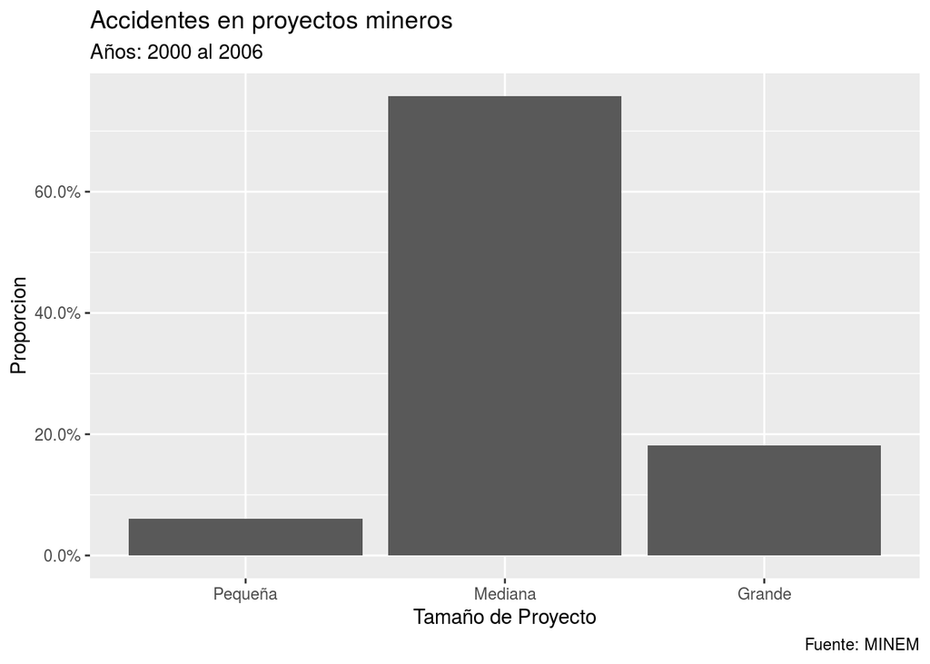

```r
base = ggplot(data=accidentes,aes(x=Tama))
bar2 = base + geom_bar(aes(y = (..count..)/sum(..count..)))
bar2= bar2 + labs(x='Tamaño de Proyecto',
                  y="Proporcion",
                  title="Accidentes en proyectos mineros",
                  subtitle = "Años: 2000 al 2006",
                  caption = "Fuente: MINEM")
bar2 + scale_y_continuous(labels = scales::percent)
```

Aquí sí, técnicamente, no podemos reordenar las modalidades. Y del análisis visual, podemos ver que los accidentes son más frecuentes en proyectos de mediana envergadura.

**3. Medidas de Resumen**

- Centralidad:
  - La moda.
  - La mediana. La mediana ya se puede calcular en la escala ordinal y se interpreta como el valor igual o menor al 50% de los casos.

```r
# 'Median' es de "DescTools" también.
Median(accidentes$Tama)
```

```
## [1] Mediana
## Levels: Pequeña < Mediana < Grande
```

De lo anterior, vemos que el 50% de los accidentes alcanzan a los proyectos de mediana envergadura.

- Concentración: Podemos usar el indice de Herfindahl- Hirschman

```r
# 'Herfindahl' está en "DescTools"

Herfindahl(table(accidentes$Tama))
```

```
## [1] 0.610652
```

Sabiendo que hay un tipo de tamaño predominante, podemos calcular el indice de Laakso - Taagepera:

```r
1/Herfindahl(table(accidentes$Tama))
```

```
## [1] 1.637594
```

Esto indica que los accidentes en proyectos de tamaño mediano son los unicos representativos.

- Simetria. Como tenemos la mediana, tiene sentido saber si los valores menores o mayores a estos se distribuyen de manera simetrica (acampanados). Si el intervalo de confianza del coeficiente de asimetría toca cero, se asume distribución acampanada:

```r
# 'Skew' está en "DescTools"

Skew(as.numeric(accidentes$Tama),conf.level = 0.95)
```

```
##       skew     lwr.ci     upr.ci
##  0.3217603 -0.3555449  1.8561705
```

- Dispersion. Nos indica que tan lejos están los valores que no son la mediana. La medida de dispersión comunmente utilizada para ordinales es la distancia interquartil (IQR):

```r
IQR(as.numeric(accidentes$Tama))
```

```
## [1] 0
```

El resultado nos indica que no hay distancia entre el valor que está en el tercer y primer quartil. El primer cuartil quiere decir el vaor límite del 25% de lo valores más bajos, el tercer cuartil es el valor mínimo del 25% de los valores mas altos. Es decir, si la mediana es *proyectos medianos*, el primer cuartil y el tercer cuartil son el mismo valor que la mediana. De ahi que no hay dispersión.

Practique y pase a resolver estos [ejercicios](https://htmlpreview.github.io/?https://github.com/CoursesAndTutorials/Estadistica/blob/master/sesion2_ejercicio.html).

[Volver al programa del curso](https://coursesandtutorials.github.io/Estadistica/)